# Pyrmont data

Onwards!

Barnabé Monnot https://twitter.com/barnabemonnot (Robust Incentives Group, Ethereum Foundation)https://github.com/ethereum/rig  
2020-11-19

## Finding the declared client

We associate each validator index to a client among Lighthouse, Prysm, Nimbus, Teku and “undecided”. To do so, for each canonical block produced, we inspect the graffiti. We associate the block to a client whenever the name of the client features in the graffiti (with a case-insensitive search). When the first four characters of the graffiti are `poap`, we check the last character: when the character is “a”, “b”, “c”, “d” or “e”, we guess the client producing the block is (respectively) Prysm, Lighthouse, Teku, Nimbus or Lodestar. Due to the low prevalence of Lodestar blocks, we have decided to remove it from the analysis.

We assume that a validator index is using the latest recorded client obtained from a block produced by that validator.

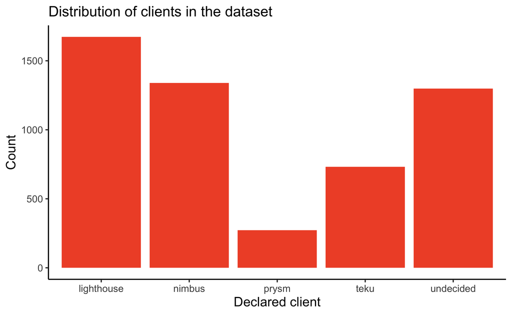

### Epoch 0 to 99

A moment in time, between 2020-08-04 13:00:08 and 2020-08-04 23:40:08.

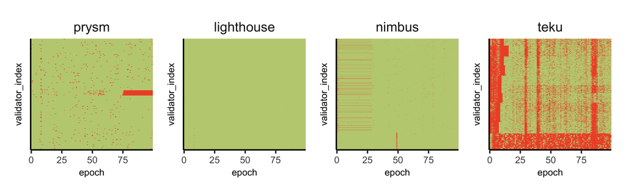

### Epoch 100 to 219

A moment in time, between 2020-08-04 23:40:08 and 2020-08-05 12:28:08.

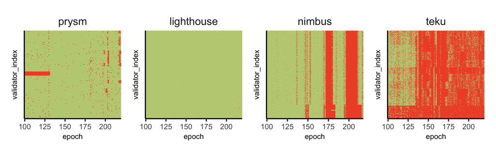